# Time Series Analysis of the Online Retail Dataset

# 1 Load Data

We first want to load our datasets and prepare them for some simple association rules mining.

```r
tnx_data_tbl <- read_rds("data/retail_data_cleaned_tbl.rds")

tnx_data_tbl %>% glimpse()
```

```
## Rows: 1,044,848
## Columns: 23
## $ row_id            <chr> "ROW0000001", "ROW0000002", "ROW0000003", "ROW000000…
## $ excel_sheet       <chr> "Year 2009-2010", "Year 2009-2010", "Year 2009-2010"…
## $ invoice_id        <chr> "489434", "489434", "489434", "489434", "489434", "4…
## $ stock_code        <chr> "85048", "79323P", "79323W", "22041", "21232", "2206…
## $ description       <chr> "15CM CHRISTMAS GLASS BALL 20 LIGHTS", "PINK CHERRY …
## $ quantity          <dbl> 12, 12, 12, 48, 24, 24, 24, 10, 12, 12, 24, 12, 10, …
## $ invoice_date      <date> 2009-12-01, 2009-12-01, 2009-12-01, 2009-12-01, 200…
## $ price             <dbl> 6.95, 6.75, 6.75, 2.10, 1.25, 1.65, 1.25, 5.95, 2.55…
## $ customer_id       <chr> "13085", "13085", "13085", "13085", "13085", "13085"…
## $ country           <chr> "United Kingdom", "United Kingdom", "United Kingdom"…
## $ stock_code_upr    <chr> "85048", "79323P", "79323W", "22041", "21232", "2206…
## $ cancellation      <lgl> FALSE, FALSE, FALSE, FALSE, FALSE, FALSE, FALSE, FAL…
## $ invoice_dttm      <dttm> 2009-12-01 07:45:00, 2009-12-01 07:45:00, 2009-12-0…
## $ invoice_month     <fct> December, December, December, December, December, De…
## $ invoice_dow       <fct> Tuesday, Tuesday, Tuesday, Tuesday, Tuesday, Tuesday…
## $ invoice_dom       <chr> "01", "01", "01", "01", "01", "01", "01", "01", "01"…
## $ invoice_hour      <chr> "07", "07", "07", "07", "07", "07", "07", "07", "07"…
## $ invoice_minute    <chr> "45", "45", "45", "45", "45", "45", "45", "45", "45"…
## $ invoice_woy       <chr> "49", "49", "49", "49", "49", "49", "49", "49", "49"…
## $ invoice_ym        <chr> "200912", "200912", "200912", "200912", "200912", "2…
## $ stock_value       <dbl> 83.40, 81.00, 81.00, 100.80, 30.00, 39.60, 30.00, 59…
## $ invoice_monthprop <dbl> 0.04347826, 0.04347826, 0.04347826, 0.04347826, 0.04…
## $ exclude           <lgl> FALSE, FALSE, FALSE, FALSE, FALSE, FALSE, FALSE, FAL…
```

To use our rules mining we just need the invoice data and the stock code, so we can ignore the rest. Also, we ignore the issue of returns and just look at purchases.

```r
tnx_purchase_tbl <- tnx_data_tbl %>%
  filter(
    quantity > 0,
    exclude == FALSE
    ) %>%
  select(
    invoice_date, invoice_id, stock_code, description, customer_id,
    quantity, price, stock_value
    )

tnx_purchase_tbl %>% glimpse()
```

```
## Rows: 1,017,670
## Columns: 8
## $ invoice_date <date> 2009-12-01, 2009-12-01, 2009-12-01, 2009-12-01, 2009-12-…
## $ invoice_id   <chr> "489434", "489434", "489434", "489434", "489434", "489434…
## $ stock_code   <chr> "85048", "79323P", "79323W", "22041", "21232", "22064", "…
## $ description  <chr> "15CM CHRISTMAS GLASS BALL 20 LIGHTS", "PINK CHERRY LIGHT…
## $ customer_id  <chr> "13085", "13085", "13085", "13085", "13085", "13085", "13…
## $ quantity     <dbl> 12, 12, 12, 48, 24, 24, 24, 10, 12, 12, 24, 12, 10, 18, 3…
## $ price        <dbl> 6.95, 6.75, 6.75, 2.10, 1.25, 1.65, 1.25, 5.95, 2.55, 3.7…
## $ stock_value  <dbl> 83.40, 81.00, 81.00, 100.80, 30.00, 39.60, 30.00, 59.50, …
```

# 2 Construct Basic Time-Series

There are a number of different perspective on this data - we can look at customer-based time-series or individual items or just total revenue.

In all these cases we aggregate daily, weekly and monthly, so rather than repeating our code over and over, we construct a function to do this.

```r
construct_time_series_data <- function(data_tbl) {
  daily_tbl <- data_tbl %>%
    tq_transmute(
      mutate_fun = apply.daily,
      FUN        = sum,
      na.rm      = TRUE,
      col_rename = "amount"
      )

  weekly_tbl <- data_tbl %>%
    tq_transmute(
      mutate_fun = apply.weekly,
      FUN        = sum,
      na.rm      = TRUE,
      col_rename = "amount"
      )

  monthly_tbl <- data_tbl %>%
    tq_transmute(
      mutate_fun = apply.monthly,
      FUN        = sum,
      na.rm      = TRUE,
      col_rename = "amount"
      )

  agg_tbl <- list(
      daily   = daily_tbl,
      weekly  = weekly_tbl,
      monthly = monthly_tbl
      ) %>%
    bind_rows(.id = "period")

  return(agg_tbl)
}
```

## 2.1 Total Revenue

A revenue-based approach is the simplest, so we start there.

```r
use_data_tbl <- tnx_purchase_tbl %>%
  select(date = invoice_date, stock_value)

ts_revenue_data_tbl <- use_data_tbl %>%
  construct_time_series_data() %>%
  mutate(
    label = "total_revenue",

    .after = "period"
  )

ts_revenue_data_tbl %>% glimpse()
```

```
## Rows: 733
## Columns: 4
## $ period <chr> "daily", "daily", "daily", "daily", "daily", "daily", "daily", …
## $ label  <chr> "total_revenue", "total_revenue", "total_revenue", "total_reven…
## $ date   <date> 2009-12-01, 2009-12-02, 2009-12-03, 2009-12-04, 2009-12-05, 20…
## $ amount <dbl> 52600.88, 62053.03, 73125.24, 39499.81, 9803.05, 24475.64, 4312…
```

Now that we have constructed this simple time-series, we now want to plot them.

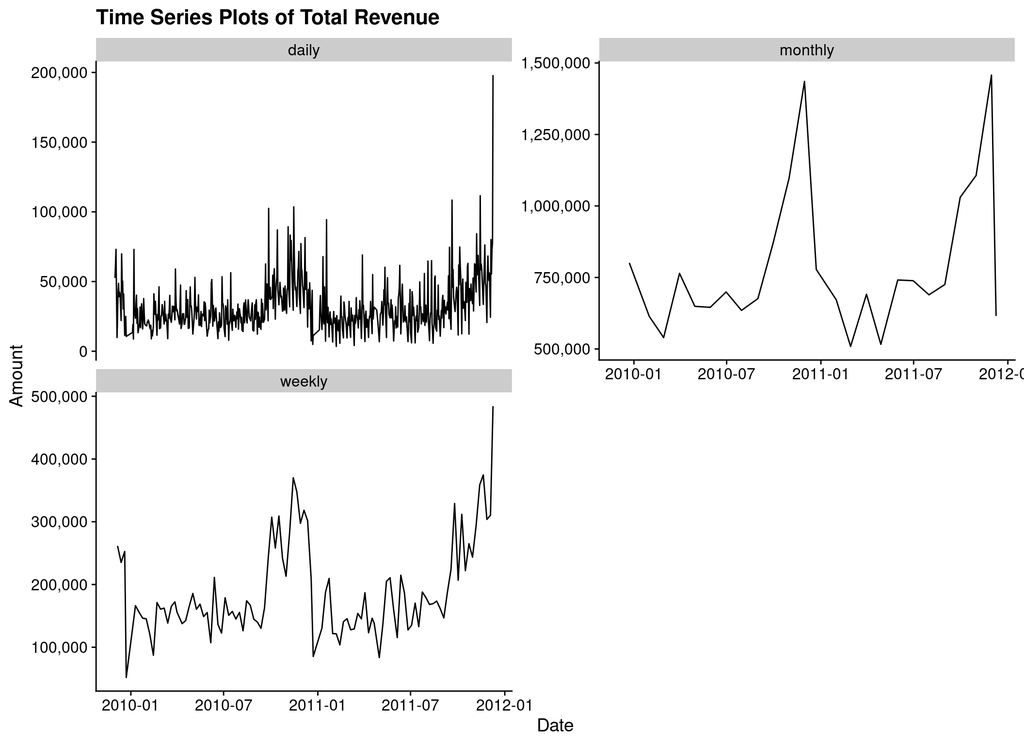

```r
ggplot(ts_revenue_data_tbl) +
  geom_line(aes(x = date, y = amount)) +
  scale_y_continuous(labels = label_comma()) +
  facet_wrap(vars(period), scales = "free_y", ncol = 2) +
  xlab("Date") +
  ylab("Amount") +
  ggtitle("Time Series Plots of Total Revenue")
```

## 2.2 Frequent Purchases

Time series plots of different item types may be useful, but only for items that have regular transactions, as otherwise the data will be mostly zero entries. Instead, we want to find items that are purchased on a regular basis and inspect those.

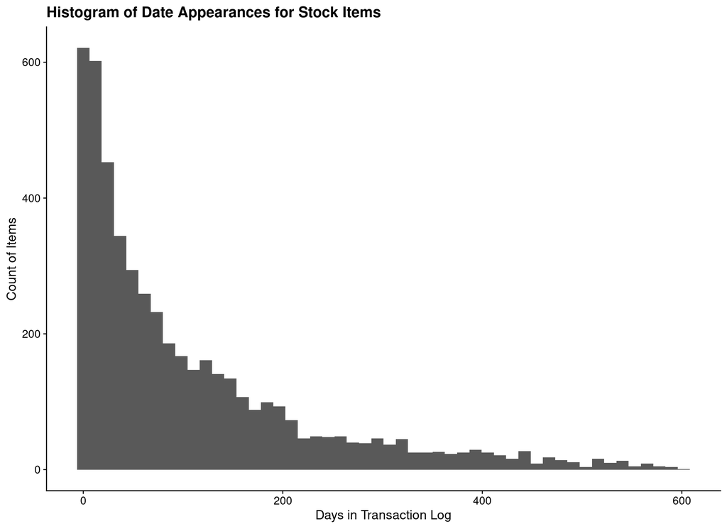

```r
stock_daycount_tbl <- tnx_purchase_tbl %>%
  select(invoice_date, stock_code) %>%
  distinct() %>%
  count(stock_code, name = "day_count")

ggplot(stock_daycount_tbl) +
  geom_histogram(aes(x = day_count), bins = 50) +
  xlab("Days in Transaction Log") +
  ylab("Count of Items") +
  ggtitle("Histogram of Date Appearances for Stock Items")
```

Rather than focus on all these items, we choose the arbitrary cut-off of the top 12 items, and construct time series of the daily sales of each of these items.

```r
use_data_tbl <- tnx_purchase_tbl %>%
  select(date = invoice_date, stock_code, stock_value)

use_stock_tbl <- stock_daycount_tbl %>%
  arrange(desc(day_count)) %>%
  slice_head(n = 12)

ts_itemsales_data_tbl <- use_data_tbl %>%
  semi_join(use_stock_tbl, by = "stock_code") %>%
  group_by(stock_code) %>%
  construct_time_series_data() %>%
  mutate(
    label = "item_sales",

    .after = "period"
  ) %>%
  ungroup()

ts_itemsales_data_tbl %>% glimpse()
```

```
## Rows: 8,534
## Columns: 5
## $ period     <chr> "daily", "daily", "daily", "daily", "daily", "daily", "dail…
## $ label      <chr> "item_sales", "item_sales", "item_sales", "item_sales", "it…
## $ stock_code <chr> "21754", "21754", "21754", "21754", "21754", "21754", "2175…
## $ date       <date> 2009-12-01, 2009-12-02, 2009-12-03, 2009-12-04, 2009-12-06…
## $ amount     <dbl> 315.48, 376.08, 160.88, 59.96, 71.40, 161.57, 77.35, 249.98…
```

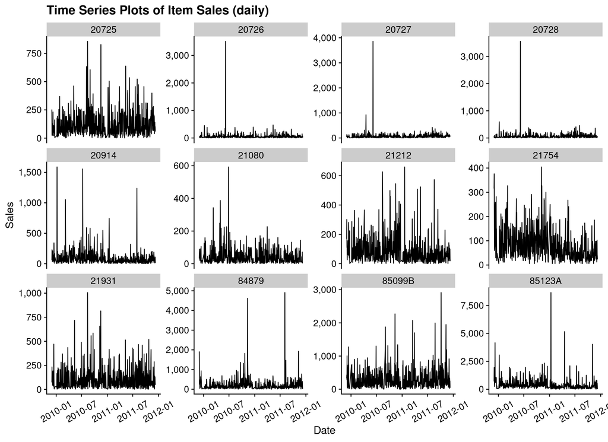

```r
ggplot(ts_itemsales_data_tbl %>% filter(period == "daily")) +
  geom_line(aes(x = date, y = amount)) +
  scale_y_continuous(labels = label_comma()) +
  facet_wrap(vars(stock_code), scales = "free_y") +
  xlab("Date") +
  ylab("Sales") +
  ggtitle("Time Series Plots of Item Sales (daily)") +
  theme(axis.text.x = element_text(angle = 30, vjust = 0.5))
```

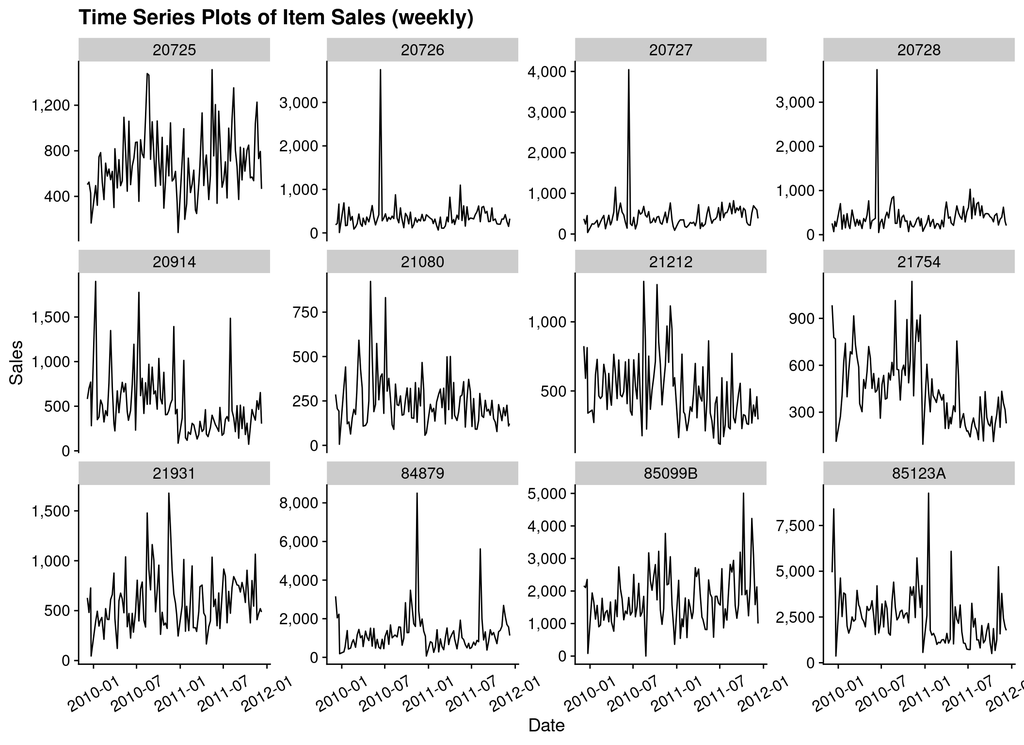

```r
ggplot(ts_itemsales_data_tbl %>% filter(period == "weekly")) +
  geom_line(aes(x = date, y = amount)) +
  scale_y_continuous(labels = label_comma()) +
  facet_wrap(vars(stock_code), scales = "free_y") +
  xlab("Date") +
  ylab("Sales") +
  ggtitle("Time Series Plots of Item Sales (weekly)") +
  theme(axis.text.x = element_text(angle = 30, vjust = 0.5))
```

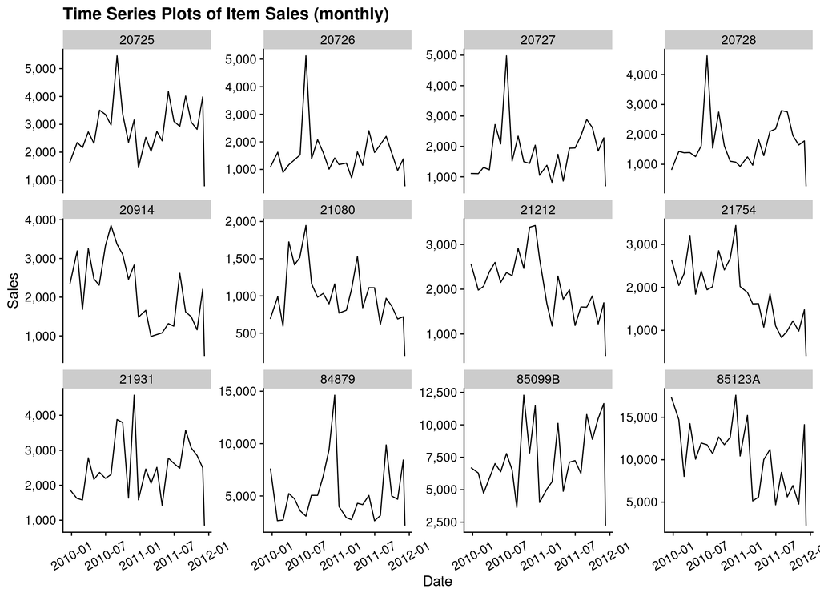

```r
ggplot(ts_itemsales_data_tbl %>% filter(period == "monthly")) +
  geom_line(aes(x = date, y = amount)) +
  scale_y_continuous(labels = label_comma()) +
  facet_wrap(vars(stock_code), scales = "free_y") +
  xlab("Date") +
  ylab("Sales") +
  ggtitle("Time Series Plots of Item Sales (monthly)") +
  theme(axis.text.x = element_text(angle = 30, vjust = 0.5))
```